# Case 31 - Summary of Data Analysis for R3, R6, and R4

Author

Willy Su

Published

November 24, 2026

# 1 Data Preparation

## 1.1 Dataset Overview

```r
data.frame(
  Description = c("Number of Observations",
                  "Number of Variables"),
  Value = c(nrow(efcu), ncol(efcu))
) |>
  kable()
```

Table 1: Overview of the Case 31 Dataset

| Description | Value |
| --- | --- |
| Number of Observations | 128 |
| Number of Variables | 53 |

# 2 R3: Attitudes Toward Credit Union Employees

This research question examines members’ attitudes toward credit union employees using survey items Q3 through Q6.

## 2.1 Descriptive Statistics

```r
r3_summary <- do.call(rbind, lapply(r3_vars, function(v) {
  x <- as.numeric(efcu[[v]])
  x <- x[x %in% 1:5]

  data.frame(
    Question = toupper(v),
    N = length(x),
    Mean = round(mean(x), 3),
    SD = round(sd(x), 3),
    Minimum = min(x),
    Maximum = max(x)
  )
}))

kable(r3_summary)
```

Table 2: Descriptive Statistics for Attitudes Toward Credit Union Employees

| Question | N | Mean | SD | Minimum | Maximum |
| --- | --- | --- | --- | --- | --- |
| Q3 | 128 | 4.352 | 0.659 | 3 | 5 |
| Q4 | 128 | 4.312 | 0.696 | 2 | 5 |
| Q5 | 128 | 4.078 | 0.659 | 3 | 5 |
| Q6 | 128 | 4.078 | 0.790 | 2 | 5 |

## 2.2 One-Sample t-test

A one-sample t-test was conducted for each survey item to determine whether members’ attitudes toward credit union employees differed significantly from the neutral midpoint of 3.

```r
r3_tests <- do.call(rbind, lapply(r3_vars, function(v) {
  x <- as.numeric(efcu[[v]])
  x <- x[x %in% 1:5]

  test <- t.test(x, mu = 3)

  data.frame(
    Question = toupper(v),
    N = length(x),
    Mean = round(mean(x), 3),
    SD = round(sd(x), 3),
    t = round(as.numeric(test$statistic), 3),
    df = as.numeric(test$parameter),
    P_Value = format.pval(test$p.value,
                         digits = 3, eps = 0.001),
    Significant = ifelse(test$p.value < 0.05,
                         "Yes", "No")
  )
}))

kable(r3_tests)
```

Table 3: One-Sample t-test Results for R3

| Question | N | Mean | SD | t | df | P_Value | Significant |
| --- | --- | --- | --- | --- | --- | --- | --- |
| Q3 | 128 | 4.352 | 0.659 | 23.198 | 127 | <0.001 | Yes |
| Q4 | 128 | 4.312 | 0.696 | 21.339 | 127 | <0.001 | Yes |
| Q5 | 128 | 4.078 | 0.659 | 18.498 | 127 | <0.001 | Yes |
| Q6 | 128 | 4.078 | 0.790 | 15.444 | 127 | <0.001 | Yes |

## 2.3 Data Visualization

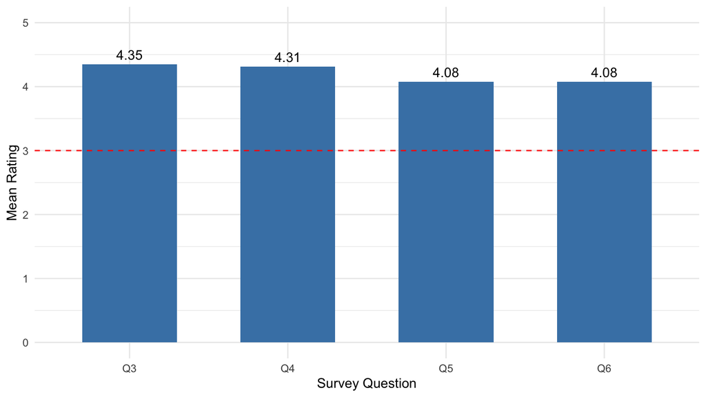

Figure 1: Mean Ratings of Attitudes Toward Credit Union Employees

```r
ggplot(r3_summary, aes(x = Question, y = Mean)) +
  geom_col(fill = "steelblue", width = 0.6) +
  geom_hline(
    yintercept = 3,
    linetype = "dashed",
    color = "red"
  ) +
  geom_text(
    aes(label = sprintf("%.2f", Mean)),
    vjust = -0.5
  ) +
  scale_y_continuous(
    limits = c(0, 5),
    breaks = 0:5
  ) +
  labs(
    x = "Survey Question",
    y = "Mean Rating"
  ) +
  theme_minimal()
```

## 2.4 Findings and Insights

Members generally have positive attitudes toward credit union employees. The mean ratings for Q3 through Q6 range from 4.078 to 4.352, indicating favorable perceptions of employee proficiencies.

All four mean ratings are significantly higher than the neutral midpoint of 3 (p < .001). Q3 received the highest mean rating (M = 4.352), followed by Q4 (M = 4.312). Q5 and Q6 received slightly lower but still positive ratings (M = 4.078).

These findings suggest that employee proficiency is a strength of the credit union, although there is still room for improvement in the areas represented by Q5 and Q6.

## 2.5 Composite Scale: Employee Proficiency

```r
efcu$Att_Employee <- rowMeans(
  efcu[, c("q3", "q4", "q5", "q6")],
  na.rm = FALSE
)

x <- na.omit(efcu$Att_Employee)

data.frame(
  Variable = "Att_Employee",
  N = length(x),
  Mean = round(mean(x), 3),
  SD = round(sd(x), 3),
  Minimum = min(x),
  Maximum = max(x)
) |>
  kable()
```

Table 4: Descriptive Statistics for Employee Proficiency

| Variable | N | Mean | SD | Minimum | Maximum |
| --- | --- | --- | --- | --- | --- |
| Att_Employee | 128 | 4.205 | 0.594 | 2.75 | 5 |

## 2.6 One-Sample t-test for Employee Proficiency

```r
employee_test <- t.test(
  efcu$Att_Employee,
  mu = 3
)

data.frame(
  Variable = "Att_Employee",
  Mean = round(mean(efcu$Att_Employee, na.rm = TRUE), 3),
  t = round(as.numeric(employee_test$statistic), 3),
  df = as.numeric(employee_test$parameter),
  P_Value = format.pval(employee_test$p.value,
                        digits = 3, eps = 0.001),
  Lower_CI = round(employee_test$conf.int[1], 3),
  Upper_CI = round(employee_test$conf.int[2], 3)
) |>
  kable()
```

Table 5: One-Sample t-test for Employee Proficiency

| Variable | Mean | t | df | P_Value | Lower_CI | Upper_CI |
| --- | --- | --- | --- | --- | --- | --- |
| Att_Employee | 4.205 | 22.954 | 127 | <0.001 | 4.101 | 4.309 |

The composite scale for employee proficiency has a mean of 4.205 (SD = 0.594). The one-sample t-test indicates that the mean is significantly higher than the neutral midpoint of 3, t(127) = 22.954, p < .001, 95% CI [4.101, 4.309].

These results indicate that members have favorable attitudes toward credit union employees.

# 3 R6: Operational Effectiveness

This research question examines members’ perceptions of the operational effectiveness of the credit union.

## 3.1 Data Preparation

## 3.2 Data Recoding

Q37 is reverse-coded so that higher scores represent more favorable evaluations of operational effectiveness. No Opinion responses are treated as missing values.

```r
efcu$Q37_r <- ifelse(
  efcu$q37 %in% 1:5,
  6 - as.numeric(efcu$q37),
  NA_real_
)

table(
  Original = efcu$q37,
  Recoded = efcu$Q37_r,
  useNA = "ifany"
)
```

Table 6: Recoding of Overall Operational Effectiveness

```
        Recoded
Original  1  2  3  4  5 <NA>
    1     0  0  0  0 31    0
    2     0  0  0 71  0    0
    3     0  0 16  0  0    0
    4     0  2  0  0  0    0
    5     1  0  0  0  0    0
    <NA>  0  0  0  0  0    7
```

Q9 retains its original response categories. Q10 is reverse-coded so that higher scores indicate better statement accuracy. Q11 and Q12 are recoded so that Yes = 2 and No = 1. Undefined responses are treated as missing values.

```r
efcu$q9_r <- ifelse(
  efcu$q9 %in% 1:5,
  as.numeric(efcu$q9),
  NA_real_
)

efcu$q10_r <- ifelse(
  efcu$q10 %in% 1:4,
  5 - as.numeric(efcu$q10),
  NA_real_
)

efcu$q11_r <- ifelse(
  efcu$q11 %in% 1:2,
  3 - as.numeric(efcu$q11),
  NA_real_
)

efcu$q12_r <- ifelse(
  efcu$q12 %in% 1:2,
  3 - as.numeric(efcu$q12),
  NA_real_
)

r6_chi_vars <- c("q9_r", "q10_r", "q11_r", "q12_r")

r6_valid <- data.frame(
  Question = r6_chi_vars,
  Valid = sapply(efcu[r6_chi_vars],
                 function(x) sum(!is.na(x))),
  Missing = sapply(efcu[r6_chi_vars],
                   function(x) sum(is.na(x)))
)

kable(r6_valid, row.names = FALSE)
```

Table 7: Valid and Missing Responses for Q9-Q12

| Question | Valid | Missing |
| --- | --- | --- |
| q9_r | 128 | 0 |
| q10_r | 128 | 0 |
| q11_r | 128 | 0 |
| q12_r | 106 | 22 |

## 3.3 Descriptive Statistics

Frequency and percentage distributions are used to summarize members’ responses to Q9 through Q12. Missing responses are excluded from the percentage calculations.

```r
r6_frequency <- do.call(rbind, lapply(r6_chi_vars, function(v) {
  x <- na.omit(efcu[[v]])
  freq <- table(x)

  data.frame(
    Question = toupper(sub("_r$", "", v)),
    Response = names(freq),
    Frequency = as.numeric(freq),
    Percentage = round(
      as.numeric(prop.table(freq)) * 100, 2
    )
  )
}))

kable(r6_frequency, row.names = FALSE)
```

Table 8: Frequency and Percentage Distributions for Q9-Q12

| Question | Response | Frequency | Percentage |
| --- | --- | --- | --- |
| Q9 | 3 | 99 | 77.34 |
| Q9 | 4 | 29 | 22.66 |
| Q10 | 1 | 2 | 1.56 |
| Q10 | 2 | 4 | 3.12 |
| Q10 | 3 | 54 | 42.19 |
| Q10 | 4 | 68 | 53.12 |
| Q11 | 1 | 3 | 2.34 |
| Q11 | 2 | 125 | 97.66 |
| Q12 | 1 | 32 | 30.19 |
| Q12 | 2 | 74 | 69.81 |

## 3.4 Chi-Square Goodness-of-Fit Test

Chi-square goodness-of-fit tests are conducted to determine whether the observed response distributions differ significantly from equal expected proportions.

```r
r6_levels <- list(
  q9_r = 1:5,
  q10_r = 1:4,
  q11_r = 1:2,
  q12_r = 1:2
)

r6_chi_tests <- do.call(rbind, lapply(r6_chi_vars, function(v) {
  x <- na.omit(efcu[[v]])
  freq <- table(factor(x, levels = r6_levels[[v]]))
  test <- chisq.test(freq)

  data.frame(
    Question = toupper(sub("_r$", "", v)),
    N = length(x),
    Chi_Square = round(as.numeric(test$statistic), 3),
    df = as.numeric(test$parameter),
    P_Value = format.pval(test$p.value,
                         digits = 3, eps = 0.001),
    Significant = ifelse(test$p.value < 0.05,
                         "Yes", "No")
  )
}))

kable(r6_chi_tests, row.names = FALSE)
```

Table 9: Chi-Square Goodness-of-Fit Tests for Q9-Q12

| Question | N | Chi_Square | df | P_Value | Significant |
| --- | --- | --- | --- | --- | --- |
| Q9 | 128 | 287.703 | 4 | <0.001 | Yes |
| Q10 | 128 | 108.250 | 3 | <0.001 | Yes |
| Q11 | 128 | 116.281 | 1 | <0.001 | Yes |
| Q12 | 106 | 16.642 | 1 | <0.001 | Yes |

## 3.5 Descriptive Statistics for Q31-Q34 and Q37

Descriptive statistics are calculated to summarize members’ evaluations of operational effectiveness. Higher scores represent more favorable evaluations for positively worded items.

```r
r6_rating_vars <- c("q31", "q32", "q33", "q34", "Q37_r")

r6_summary <- do.call(rbind, lapply(r6_rating_vars, function(v) {
  x <- as.numeric(efcu[[v]])
  x <- x[x %in% 1:5]

  data.frame(
    Question = toupper(v),
    N = length(x),
    Mean = round(mean(x), 3),
    SD = round(sd(x), 3),
    Minimum = min(x),
    Maximum = max(x)
  )
}))

kable(r6_summary, row.names = FALSE)
```

Table 10: Descriptive Statistics for Operational Effectiveness

| Question | N | Mean | SD | Minimum | Maximum |
| --- | --- | --- | --- | --- | --- |
| Q31 | 128 | 3.945 | 0.679 | 1 | 5 |
| Q32 | 128 | 3.719 | 0.793 | 2 | 5 |
| Q33 | 128 | 3.594 | 0.681 | 2 | 5 |
| Q34 | 128 | 3.461 | 0.783 | 1 | 5 |
| Q37_R | 121 | 4.066 | 0.727 | 1 | 5 |

## 3.6 One-Sample t-test for Operational Effectiveness

One-sample t-tests are conducted to determine whether the mean ratings for Q31-Q34 and Q37 differ significantly from the midpoint of 3.

```r
r6_tests <- do.call(rbind, lapply(r6_rating_vars, function(v) {
  x <- as.numeric(efcu[[v]])
  x <- x[x %in% 1:5]

  test <- t.test(x, mu = 3)

  data.frame(
    Question = toupper(v),
    N = length(x),
    Mean = round(mean(x), 3),
    SD = round(sd(x), 3),
    t = round(as.numeric(test$statistic), 3),
    df = as.numeric(test$parameter),
    P_Value = format.pval(test$p.value,
                         digits = 3, eps = 0.001),
    Significant = ifelse(test$p.value < 0.05,
                         "Yes", "No")
  )
}))

kable(r6_tests, row.names = FALSE)
```

Table 11: One-Sample t-tests for Operational Effectiveness

| Question | N | Mean | SD | t | df | P_Value | Significant |
| --- | --- | --- | --- | --- | --- | --- | --- |
| Q31 | 128 | 3.945 | 0.679 | 15.742 | 127 | <0.001 | Yes |
| Q32 | 128 | 3.719 | 0.793 | 10.254 | 127 | <0.001 | Yes |
| Q33 | 128 | 3.594 | 0.681 | 9.866 | 127 | <0.001 | Yes |
| Q34 | 128 | 3.461 | 0.783 | 6.663 | 127 | <0.001 | Yes |
| Q37_R | 121 | 4.066 | 0.727 | 16.125 | 120 | <0.001 | Yes |

## 3.7 Data Visualization

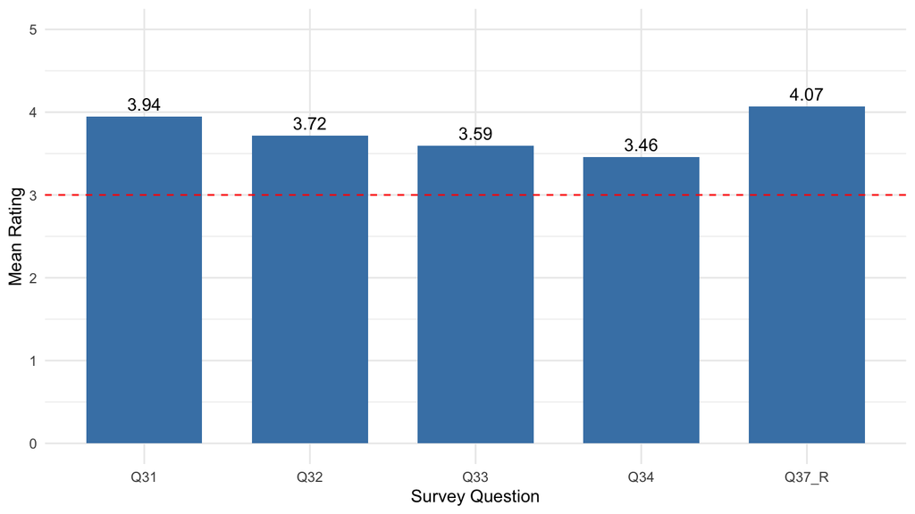

Figure 2: Mean Ratings of Operational Effectiveness

```r
ggplot(r6_summary, aes(x = Question, y = Mean)) +
  geom_col(
    fill = "steelblue",
    width = 0.7
  ) +
  geom_hline(
    yintercept = 3,
    linetype = "dashed",
    color = "red"
  ) +
  geom_text(
    aes(label = sprintf("%.2f", Mean)),
    vjust = -0.5
  ) +
  scale_y_continuous(
    limits = c(0, 5),
    breaks = 0:5
  ) +
  labs(
    x = "Survey Question",
    y = "Mean Rating"
  ) +
  theme_minimal()
```

## 3.8 Findings and Insights

The chi-square goodness-of-fit tests for Q9 through Q12 indicate that all response distributions differ significantly from equal expected proportions (p < .001).

The mean ratings for Q31 through Q34 and Q37 range from 3.461 to 4.066. All five mean ratings are significantly higher than the midpoint of 3 (p < .001), indicating generally favorable perceptions of operational effectiveness.

Q37 received the highest mean rating (M = 4.066), followed by Q31 (M = 3.945). Q34 received the lowest mean rating (M = 3.461), suggesting that simplifying loan applications may be an area for improvement.

Overall, members evaluate the credit union’s operations positively, although opportunities remain to improve operational processes.

# 4 R4a: Employee Proficiency by Member Residence

This research question examines whether attitudes toward employee proficiencies differ between members who live in the area of the firm’s headquarters and members who live elsewhere.

## 4.1 Data Preparation

## 4.2 Descriptive Statistics

Descriptive statistics are used to compare attitudes toward employee proficiencies between members living in the headquarters area and those living elsewhere.

```r
efcu$Residence <- factor(
  efcu$q38,
  levels = c(1, 2),
  labels = c("Headquarters Area", "Elsewhere")
)

r4a_summary <- efcu |>
  dplyr::group_by(Residence) |>
  dplyr::summarise(
    N = sum(!is.na(Att_Employee)),
    Mean = round(mean(Att_Employee, na.rm = TRUE), 3),
    SD = round(sd(Att_Employee, na.rm = TRUE), 3),
    .groups = "drop"
  )

knitr::kable(r4a_summary)
```

Table 12: Employee Proficiency by Member Residence

| Residence | N | Mean | SD |
| --- | --- | --- | --- |
| Headquarters Area | 57 | 4.281 | 0.575 |
| Elsewhere | 71 | 4.144 | 0.606 |

## 4.3 Independent Samples t-test

An independent samples t-test is conducted to determine whether attitudes toward employee proficiencies differ significantly between members living in the headquarters area and those living elsewhere.

```r
r4a_test <- t.test(
  Att_Employee ~ Residence,
  data = efcu,
  var.equal = FALSE
)

data.frame(
  t = round(as.numeric(r4a_test$statistic), 3),
  df = round(as.numeric(r4a_test$parameter), 3),
  P_Value = format.pval(
    r4a_test$p.value,
    digits = 3, eps = 0.001
  ),
  Lower_CI = round(r4a_test$conf.int[1], 3),
  Upper_CI = round(r4a_test$conf.int[2], 3),
  Significant = ifelse(
    r4a_test$p.value < 0.05, "Yes", "No"
  )
) |>
  knitr::kable()
```

Table 13: Independent Samples t-test by Member Residence

| t | df | P_Value | Lower_CI | Upper_CI | Significant |
| --- | --- | --- | --- | --- | --- |
| 1.302 | 122.493 | 0.195 | -0.071 | 0.344 | No |

## 4.4 Data Visualization

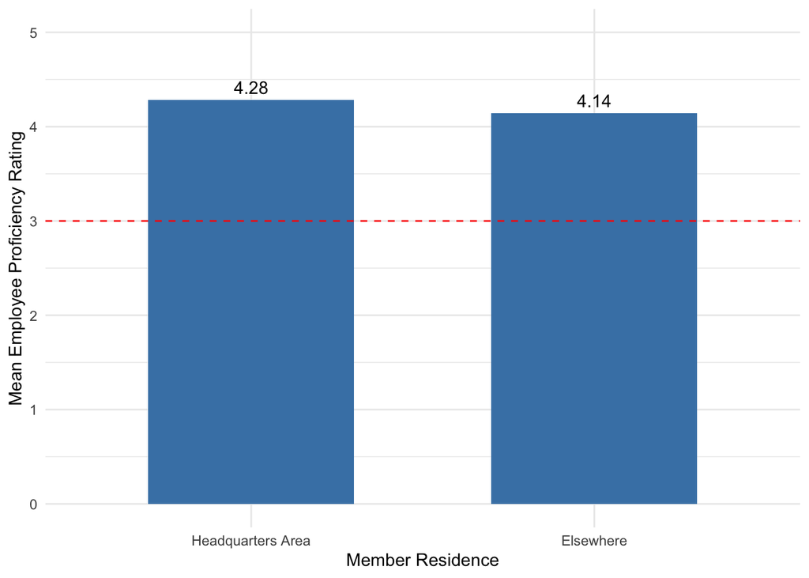

Figure 3: Mean Employee Proficiency Ratings by Member Residence

```r
ggplot(r4a_summary,
       aes(x = Residence, y = Mean)) +
  geom_col(
    fill = "steelblue",
    width = 0.6
  ) +
  geom_hline(
    yintercept = 3,
    linetype = "dashed",
    color = "red"
  ) +
  geom_text(
    aes(label = sprintf("%.2f", Mean)),
    vjust = -0.5
  ) +
  scale_y_continuous(
    limits = c(0, 5),
    breaks = 0:5
  ) +
  labs(
    x = "Member Residence",
    y = "Mean Employee Proficiency Rating"
  ) +
  theme_minimal()
```

## 4.5 Findings and Insights

Members living in the headquarters area reported a slightly higher mean employee proficiency rating (M = 4.281, SD = 0.575) than members living elsewhere (M = 4.144, SD = 0.606).

However, the independent samples t-test revealed no statistically significant difference between the two groups (t = 1.302, p = 0.1955).

These findings suggest that members generally have positive perceptions of employee proficiencies, regardless of their residential location. There is insufficient evidence to conclude that employee proficiency ratings differ by member residence.

# 5 R4b: Awareness of Services by Member Residence

This research question examines whether awareness of credit union services differs between members living in the headquarters area and those living elsewhere.

## 5.1 Data Preparation

## 5.2 Data Recoding

Q13–Q26 are reverse-coded so that higher scores represent greater awareness and usage of credit union services. Responses outside the valid range are treated as missing values.

```r
for (v in r4b_vars) {
  x <- as.numeric(efcu[[v]])

  efcu[[paste0(v, "_r")]] <- ifelse(
    x %in% 1:3,
    4 - x,
    NA_real_
  )
}

r4b_recoded <- paste0(r4b_vars, "_r")

r4b_valid <- data.frame(
  Question = toupper(r4b_vars),
  Valid = sapply(efcu[r4b_recoded],
                 function(x) sum(!is.na(x))),
  Missing = sapply(efcu[r4b_recoded],
                   function(x) sum(is.na(x)))
)

knitr::kable(r4b_valid, row.names = FALSE)
```

Table 14: Valid and Missing Responses for Q13–Q26

| Question | Valid | Missing |
| --- | --- | --- |
| Q13 | 128 | 0 |
| Q14 | 128 | 0 |
| Q15 | 128 | 0 |
| Q16 | 128 | 0 |
| Q17 | 128 | 0 |
| Q18 | 128 | 0 |
| Q19 | 128 | 0 |
| Q20 | 128 | 0 |
| Q21 | 128 | 0 |
| Q22 | 128 | 0 |
| Q23 | 128 | 0 |
| Q24 | 128 | 0 |
| Q25 | 128 | 0 |
| Q26 | 128 | 0 |

## 5.3 Two-way Cross-tabulation

Cross-tabulations are used to compare awareness and usage of credit union services between members living in the headquarters area and those living elsewhere. Row percentages are calculated to compare response distributions across residence groups.

```r
r4b_crosstab <- do.call(rbind, lapply(r4b_recoded, function(v) {

  tab <- table(
    Residence = efcu$Residence,
    Awareness = factor(
      efcu[[v]],
      levels = c(1, 2, 3),
      labels = c(
        "Unaware",
        "Aware but Not Used",
        "Aware and Used"
      )
    )
  )

  pct <- prop.table(tab, margin = 1) * 100

  data.frame(
    Question = toupper(sub("_r$", "", v)),
    Residence = rownames(tab),
    Unaware = round(pct[, 1], 2),
    Aware_Not_Used = round(pct[, 2], 2),
    Aware_Used = round(pct[, 3], 2)
  )
}))

knitr::kable(r4b_crosstab, row.names = FALSE)
```

Table 15: Service Awareness by Member Residence

| Question | Residence | Unaware | Aware_Not_Used | Aware_Used |
| --- | --- | --- | --- | --- |
| Q13 | Headquarters Area | 59.65 | 28.07 | 12.28 |
| Q13 | Elsewhere | 69.01 | 22.54 | 8.45 |
| Q14 | Headquarters Area | 38.60 | 54.39 | 7.02 |
| Q14 | Elsewhere | 33.80 | 54.93 | 11.27 |
| Q15 | Headquarters Area | 29.82 | 61.40 | 8.77 |
| Q15 | Elsewhere | 35.21 | 56.34 | 8.45 |
| Q16 | Headquarters Area | 28.07 | 47.37 | 24.56 |
| Q16 | Elsewhere | 26.76 | 52.11 | 21.13 |
| Q17 | Headquarters Area | 17.54 | 38.60 | 43.86 |
| Q17 | Elsewhere | 7.04 | 49.30 | 43.66 |
| Q18 | Headquarters Area | 7.02 | 78.95 | 14.04 |
| Q18 | Elsewhere | 1.41 | 83.10 | 15.49 |
| Q19 | Headquarters Area | 3.51 | 78.95 | 17.54 |
| Q19 | Elsewhere | 4.23 | 76.06 | 19.72 |
| Q20 | Headquarters Area | 14.04 | 75.44 | 10.53 |
| Q20 | Elsewhere | 5.63 | 83.10 | 11.27 |
| Q21 | Headquarters Area | 26.32 | 66.67 | 7.02 |
| Q21 | Elsewhere | 25.35 | 63.38 | 11.27 |
| Q22 | Headquarters Area | 33.33 | 57.89 | 8.77 |
| Q22 | Elsewhere | 25.35 | 66.20 | 8.45 |
| Q23 | Headquarters Area | 38.60 | 52.63 | 8.77 |
| Q23 | Elsewhere | 46.48 | 42.25 | 11.27 |
| Q24 | Headquarters Area | 54.39 | 43.86 | 1.75 |
| Q24 | Elsewhere | 53.52 | 45.07 | 1.41 |
| Q25 | Headquarters Area | 63.16 | 36.84 | 0.00 |
| Q25 | Elsewhere | 59.15 | 35.21 | 5.63 |
| Q26 | Headquarters Area | 0.00 | 64.91 | 35.09 |
| Q26 | Elsewhere | 0.00 | 60.56 | 39.44 |

## 5.4 Chi-Square Test of Independence

Chi-square tests of independence are conducted to determine whether awareness and usage of credit union services are significantly associated with member residence.

```r
r4b_chi_tests <- do.call(rbind, lapply(r4b_recoded, function(v) {

  tab <- table(
    efcu$Residence,
    factor(efcu[[v]], levels = 1:3)
  )

  tab <- tab[rowSums(tab) > 0,
             colSums(tab) > 0, drop = FALSE]

  test <- suppressWarnings(chisq.test(tab))

  data.frame(
    Question = toupper(sub("_r$", "", v)),
    N = sum(tab),
    Chi_Square = round(as.numeric(test$statistic), 3),
    df = as.numeric(test$parameter),
    P_Value = format.pval(
      test$p.value, digits = 3, eps = 0.001
    ),
    Min_Expected = round(min(test$expected), 2),
    Significant = ifelse(
      test$p.value < 0.05, "Yes", "No"
    )
  )
}))

knitr::kable(r4b_chi_tests, row.names = FALSE)
```

Table 16: Chi-Square Tests of Independence for Q13–Q26

| Question | N | Chi_Square | df | P_Value | Min_Expected | Significant |
| --- | --- | --- | --- | --- | --- | --- |
| Q13 | 128 | 1.272 | 2 | 0.529 | 5.79 | No |
| Q14 | 128 | 0.813 | 2 | 0.666 | 5.34 | No |
| Q15 | 128 | 0.422 | 2 | 0.81 | 4.90 | No |
| Q16 | 128 | 0.327 | 2 | 0.849 | 12.91 | No |
| Q17 | 128 | 3.789 | 2 | 0.15 | 6.68 | No |
| Q18 | 128 | 2.659 | 2 | 0.265 | 2.23 | No |
| Q19 | 128 | 0.155 | 2 | 0.925 | 2.23 | No |
| Q20 | 128 | 2.629 | 2 | 0.269 | 5.34 | No |
| Q21 | 128 | 0.673 | 2 | 0.714 | 5.34 | No |
| Q22 | 128 | 1.049 | 2 | 0.592 | 4.90 | No |
| Q23 | 128 | 1.378 | 2 | 0.502 | 5.79 | No |
| Q24 | 128 | 0.039 | 2 | 0.981 | 0.89 | No |
| Q25 | 128 | 3.318 | 2 | 0.19 | 1.78 | No |
| Q26 | 128 | 0.103 | 1 | 0.748 | 21.38 | No |

## 5.5 Additional Validation: Fisher’s Exact Test

Fisher’s exact tests are conducted for items with small expected cell frequencies to validate the chi-square test results.

```r
r4b_fisher_vars <- c(
  "q15_r", "q18_r", "q19_r",
  "q22_r", "q24_r", "q25_r"
)

r4b_fisher_tests <- do.call(rbind, lapply(
  r4b_fisher_vars, function(v) {

    tab <- table(
      efcu$Residence,
      factor(efcu[[v]], levels = 1:3)
    )

    tab <- tab[rowSums(tab) > 0,
               colSums(tab) > 0, drop = FALSE]

    test <- fisher.test(tab)

    data.frame(
      Question = toupper(sub("_r$", "", v)),
      N = sum(tab),
      P_Value = format.pval(
        test$p.value, digits = 3, eps = 0.001
      ),
      Significant = ifelse(
        test$p.value < 0.05, "Yes", "No"
      )
    )
  }
))

knitr::kable(r4b_fisher_tests, row.names = FALSE)
```

Table 17: Fisher’s Exact Tests for Small Expected Frequencies

| Question | N | P_Value | Significant |
| --- | --- | --- | --- |
| Q15 | 128 | 0.86 | No |
| Q18 | 128 | 0.319 | No |
| Q19 | 128 | 0.938 | No |
| Q22 | 128 | 0.622 | No |
| Q24 | 128 | 1 | No |
| Q25 | 128 | 0.242 | No |

## 5.6 Data Visualization

The following figure compares service awareness between members living in the headquarters area and those living elsewhere. Awareness includes members who have used the service and those who are aware of the service but have not used it.

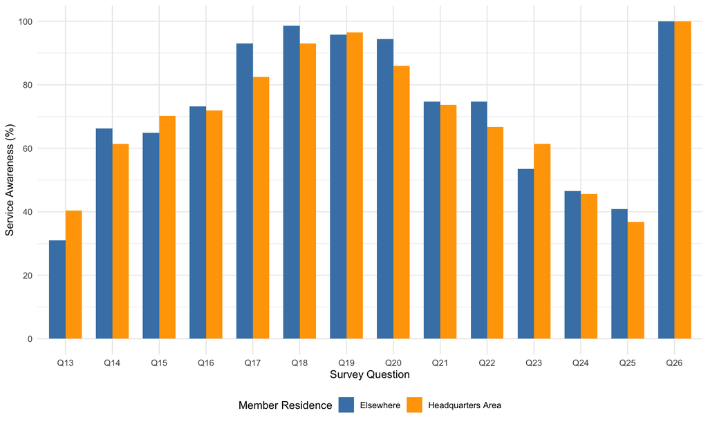

Figure 4: Service Awareness by Member Residence

```r
r4b_plot <- r4b_crosstab |>
  dplyr::mutate(
    Awareness = Aware_Not_Used + Aware_Used
  )

ggplot(
  r4b_plot,
  aes(
    x = Question,
    y = Awareness,
    fill = Residence
  )
) +
  geom_col(position = "dodge", width = 0.7) +
  scale_fill_manual(
    values = c("steelblue", "orange")
  ) +
  scale_y_continuous(
    limits = c(0, 100),
    breaks = seq(0, 100, 20)
  ) +
  labs(
    x = "Survey Question",
    y = "Service Awareness (%)",
    fill = "Member Residence"
  ) +
  theme_minimal() +
  theme(legend.position = "bottom")
```

## 5.7 Findings and Insights

The chi-square tests of independence indicate that none of the 14 service awareness and usage items (Q13–Q26) show statistically significant associations with member residence (all p-values > 0.05).

Fisher’s exact tests were also conducted for six items with small expected cell frequencies. The results support the same conclusion, with all p-values greater than 0.05.

Overall, there is insufficient statistical evidence to conclude that service awareness and usage differ between members living in the headquarters area and those living elsewhere.

These findings suggest that the credit union may consider a consistent service communication and promotion strategy across both geographic groups, while continuing to monitor individual service awareness and usage.

# 6 R4c: Operational Effectiveness by Member Residence

This research question examines whether members’ attitudes toward operational effectiveness differ between those living in the headquarters area and those living elsewhere.

## 6.1 Data Preparation

The recoded variables from R6 and the residence variable from R4a are used for this analysis.

## 6.2 Descriptive Statistics

Descriptive statistics are calculated to compare operational effectiveness ratings between members living in the headquarters area and those living elsewhere.

```r
r4c_summary <- do.call(rbind, lapply(
  r4c_rating_vars, function(v) {

    data.frame(
      Question = toupper(v),
      Residence = efcu$Residence,
      Score = as.numeric(efcu[[v]])
    ) |>
      dplyr::filter(
        !is.na(Score),
        !is.na(Residence)
      ) |>
      dplyr::group_by(Question, Residence) |>
      dplyr::summarise(
        N = dplyr::n(),
        Mean = round(mean(Score), 3),
        SD = round(sd(Score), 3),
        .groups = "drop"
      )
  }
))

knitr::kable(r4c_summary, row.names = FALSE)
```

Table 18: Operational Effectiveness by Member Residence

| Question | Residence | N | Mean | SD |
| --- | --- | --- | --- | --- |
| Q9_R | Headquarters Area | 57 | 3.211 | 0.411 |
| Q9_R | Elsewhere | 71 | 3.239 | 0.430 |
| Q10_R | Headquarters Area | 57 | 3.491 | 0.658 |
| Q10_R | Elsewhere | 71 | 3.451 | 0.628 |
| Q31 | Headquarters Area | 57 | 4.053 | 0.666 |
| Q31 | Elsewhere | 71 | 3.859 | 0.682 |
| Q32 | Headquarters Area | 57 | 3.684 | 0.805 |
| Q32 | Elsewhere | 71 | 3.746 | 0.788 |
| Q33 | Headquarters Area | 57 | 3.596 | 0.728 |
| Q33 | Elsewhere | 71 | 3.592 | 0.645 |
| Q34 | Headquarters Area | 57 | 3.281 | 0.921 |
| Q34 | Elsewhere | 71 | 3.606 | 0.621 |
| Q37_R | Headquarters Area | 54 | 4.019 | 0.658 |
| Q37_R | Elsewhere | 67 | 4.104 | 0.781 |

## 6.3 Independent Samples t-test

Independent samples t-tests are conducted to determine whether operational effectiveness ratings differ significantly between members living in the headquarters area and those living elsewhere.

Welch’s t-test is used without assuming equal population variances.

```r
r4c_tests <- do.call(rbind, lapply(
  r4c_rating_vars, function(v) {

    temp <- data.frame(
      Score = as.numeric(efcu[[v]]),
      Residence = efcu$Residence
    )

    test <- t.test(
      Score ~ Residence,
      data = temp,
      var.equal = FALSE
    )

    data.frame(
      Question = toupper(v),
      t = round(as.numeric(test$statistic), 3),
      df = round(as.numeric(test$parameter), 3),
      P_Value = format.pval(
        test$p.value,
        digits = 3,
        eps = 0.001
      ),
      Lower_CI = round(test$conf.int[1], 3),
      Upper_CI = round(test$conf.int[2], 3),
      Significant = ifelse(
        test$p.value < 0.05, "Yes", "No"
      )
    )
  }
))

knitr::kable(r4c_tests, row.names = FALSE)
```

Table 19: Independent Samples t-tests for Operational Effectiveness

| Question | t | df | P_Value | Lower_CI | Upper_CI | Significant |
| --- | --- | --- | --- | --- | --- | --- |
| Q9_R | -0.387 | 122.130 | 0.699 | -0.177 | 0.119 | No |
| Q10_R | 0.353 | 117.527 | 0.724 | -0.187 | 0.268 | No |
| Q31 | 1.616 | 121.258 | 0.109 | -0.044 | 0.431 | No |
| Q32 | -0.439 | 118.935 | 0.661 | -0.343 | 0.219 | No |
| Q33 | 0.040 | 112.932 | 0.968 | -0.239 | 0.249 | No |
| Q34 | -2.280 | 94.241 | 0.0249 | -0.608 | -0.042 | Yes |
| Q37_R | -0.657 | 118.741 | 0.513 | -0.345 | 0.173 | No |

## 6.4 Two-way Cross-tabulation

Two-way cross-tabulations are used to compare responses to Q11 and Q12 between members living in the headquarters area and those living elsewhere.

Row percentages are calculated using valid responses within each residence group.

```r
r4c_crosstab <- do.call(rbind, lapply(
  r4c_chi_vars, function(v) {

    tab <- table(
      Residence = efcu$Residence,
      Response = factor(
        efcu[[v]],
        levels = c(1, 2),
        labels = c("No", "Yes")
      )
    )

    pct <- prop.table(tab, margin = 1) * 100

    data.frame(
      Question = toupper(sub("_r$", "", v)),
      Residence = rownames(tab),
      N = rowSums(tab),
      No = as.numeric(tab[, 1]),
      Yes = as.numeric(tab[, 2]),
      No_Percentage = round(pct[, 1], 2),
      Yes_Percentage = round(pct[, 2], 2)
    )
  }
))

knitr::kable(r4c_crosstab, row.names = FALSE)
```

Table 20: Responses to Q11 and Q12 by Member Residence

| Question | Residence | N | No | Yes | No_Percentage | Yes_Percentage |
| --- | --- | --- | --- | --- | --- | --- |
| Q11 | Headquarters Area | 57 | 2 | 55 | 3.51 | 96.49 |
| Q11 | Elsewhere | 71 | 1 | 70 | 1.41 | 98.59 |
| Q12 | Headquarters Area | 49 | 18 | 31 | 36.73 | 63.27 |
| Q12 | Elsewhere | 57 | 14 | 43 | 24.56 | 75.44 |

## 6.5 Chi-Square Test of Independence

Chi-square tests of independence are conducted to determine whether responses to Q11 and Q12 are significantly associated with member residence.

Fisher’s exact test is also conducted when expected cell frequencies are below five.

```r
r4c_chi_tests <- do.call(rbind, lapply(
  r4c_chi_vars, function(v) {

    tab <- table(
      efcu$Residence,
      factor(efcu[[v]], levels = c(1, 2))
    )

    test <- suppressWarnings(chisq.test(tab))

    fisher_p <- if (min(test$expected) < 5) {
      fisher.test(tab)$p.value
    } else {
      NA_real_
    }

    final_p <- ifelse(
      is.na(fisher_p), test$p.value, fisher_p
    )

    data.frame(
      Question = toupper(sub("_r$", "", v)),
      N = sum(tab),
      Chi_Square = round(
        as.numeric(test$statistic), 3
      ),
      df = as.numeric(test$parameter),
      P_Value = round(test$p.value, 4),
      Min_Expected = round(min(test$expected), 2),
      Fisher_P = round(fisher_p, 4),
      Significant = ifelse(
        final_p < 0.05, "Yes", "No"
      )
    )
  }
))

knitr::kable(r4c_chi_tests, row.names = FALSE)
```

Table 21: Chi-Square Tests of Independence for Q11 and Q12

| Question | N | Chi_Square | df | P_Value | Min_Expected | Fisher_P | Significant |
| --- | --- | --- | --- | --- | --- | --- | --- |
| Q11 | 128 | 0.037 | 1 | 0.8471 | 1.34 | 0.5851 | No |
| Q12 | 106 | 1.320 | 1 | 0.2506 | 14.79 | NA | No |

## 6.6 Data Visualization

The following visualizations compare operational effectiveness ratings and response distributions across member residence groups.

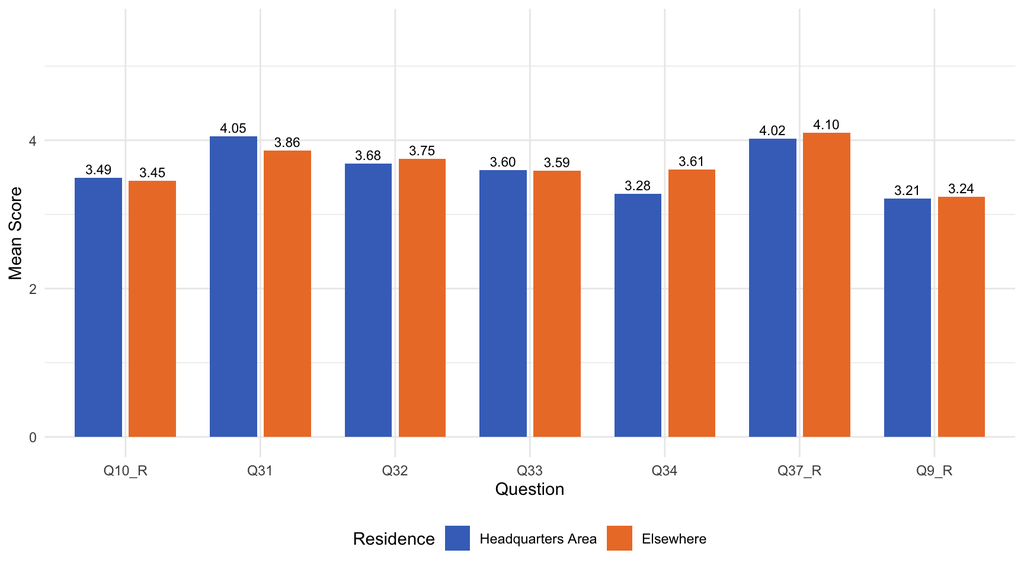

Figure 5: Mean Operational Effectiveness Ratings by Residence

```r
ggplot2::ggplot(
  r4c_summary,
  ggplot2::aes(
    x = Question,
    y = Mean,
    fill = Residence
  )
) +
  ggplot2::geom_col(
    position = ggplot2::position_dodge(0.8),
    width = 0.7
  ) +
  ggplot2::geom_text(
    ggplot2::aes(label = sprintf("%.2f", Mean)),
    position = ggplot2::position_dodge(0.8),
    vjust = -0.4,
    size = 3
  ) +
  ggplot2::scale_fill_manual(
    values = c("#4472C4", "#ED7D31")
  ) +
  ggplot2::scale_y_continuous(
    limits = c(0, 5.5)
  ) +
  ggplot2::labs(
    x = "Question",
    y = "Mean Score",
    fill = "Residence"
  ) +
  ggplot2::theme_minimal() +
  ggplot2::theme(
    legend.position = "bottom"
  )
```

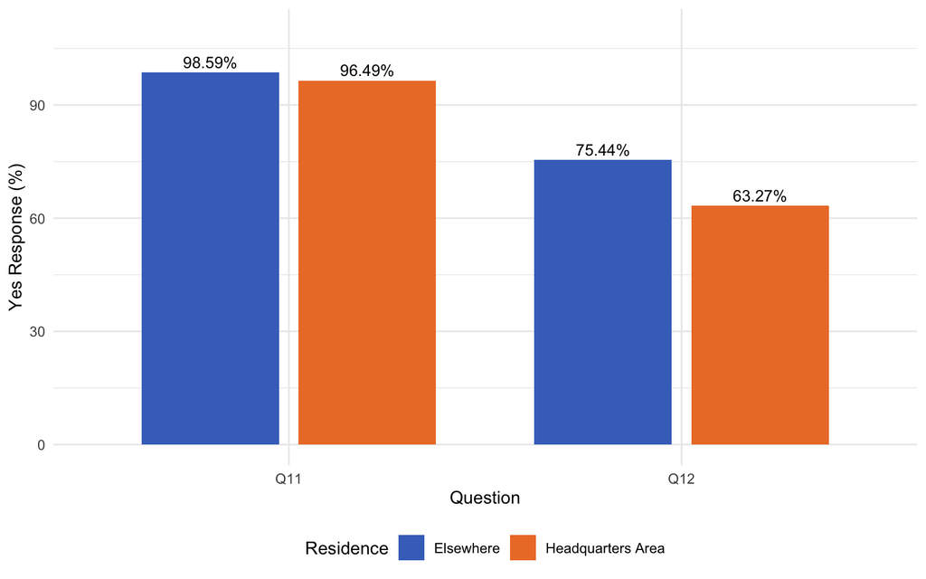

Figure 6: Yes Response Percentages by Member Residence

```r
ggplot2::ggplot(
  r4c_crosstab,
  ggplot2::aes(
    x = Question,
    y = Yes_Percentage,
    fill = Residence
  )
) +
  ggplot2::geom_col(
    position = ggplot2::position_dodge(0.8),
    width = 0.7
  ) +
  ggplot2::geom_text(
    ggplot2::aes(
      label = paste0(Yes_Percentage, "%")
    ),
    position = ggplot2::position_dodge(0.8),
    vjust = -0.4,
    size = 3.5
  ) +
  ggplot2::scale_fill_manual(
    values = c("#4472C4", "#ED7D31")
  ) +
  ggplot2::scale_y_continuous(
    limits = c(0, 110)
  ) +
  ggplot2::labs(
    x = "Question",
    y = "Yes Response (%)",
    fill = "Residence"
  ) +
  ggplot2::theme_minimal() +
  ggplot2::theme(
    legend.position = "bottom"
  )
```

## 6.7 Findings and Insights

Most operational effectiveness ratings showed no significant differences between residence groups.

Q34 was the only significant result before multiple comparison adjustment (t = -2.280, p = 0.0249). Members living elsewhere reported a higher mean rating (M = 3.61) than those living in the headquarters area (M = 3.28).

Neither Q11 (p = 0.5851) nor Q12 (p = 0.2506) showed a significant association with residence.

Overall, member residence does not appear to be a major factor in operational effectiveness. However, the credit union could further investigate the loan application experience among headquarters area members. The Q34 result should be interpreted cautiously due to multiple comparisons.

## 6.8 Appendix

### 6.8.1 GitHub Repository

[View GitHub Repository](https://github.com/WillySuu/IC11-2-Case31-Data-Analysis)

### 6.8.2 Published Presentation

[View Published Presentation](https://willysuu.github.io/IC11-2-Case31-Data-Analysis/)